# NOAA GOM Shark Models

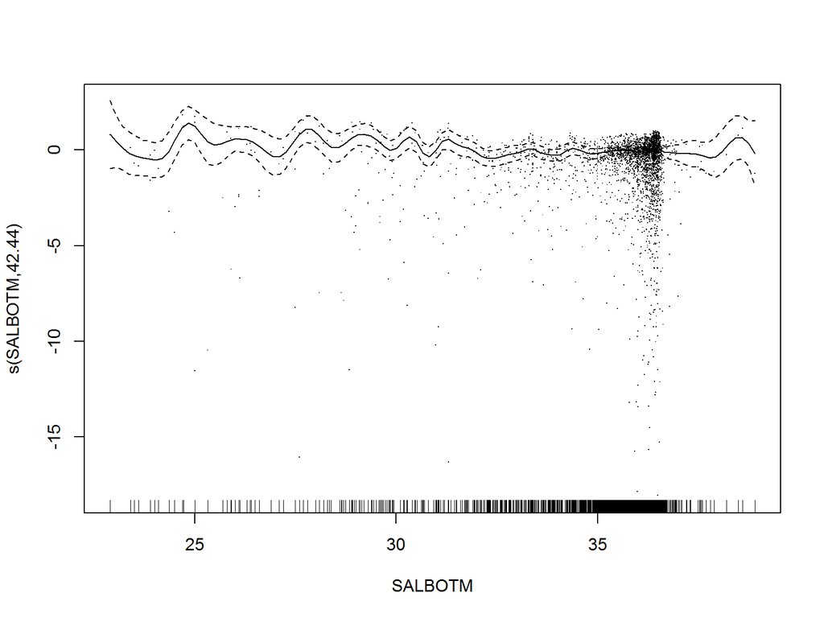

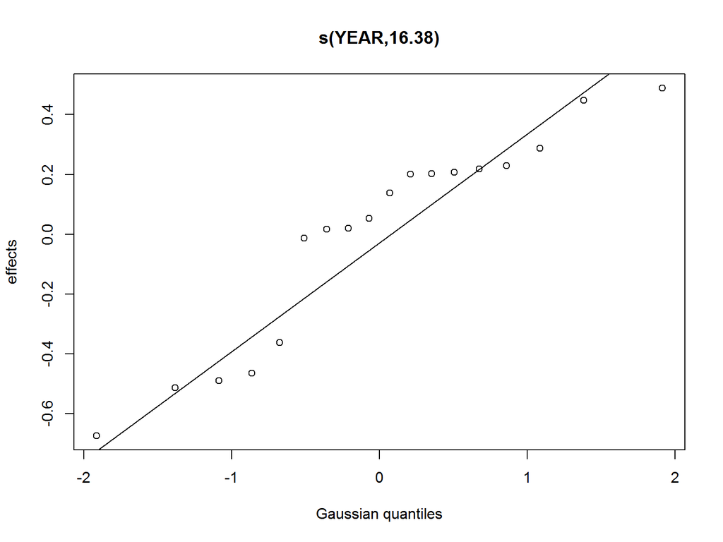

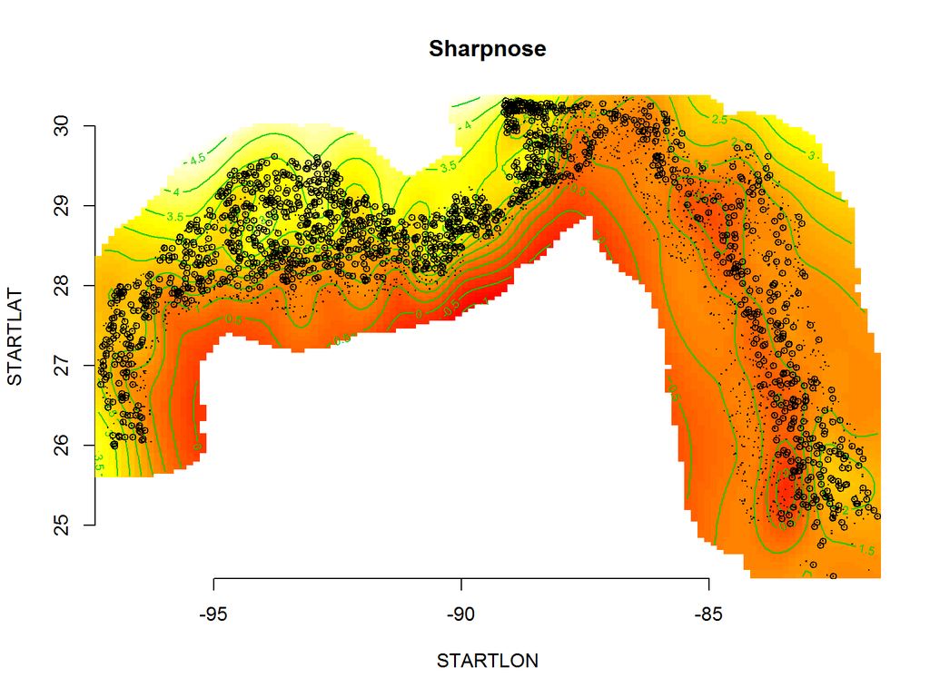

### Silky

```
##
## Family: Gamma
## Link function: log
##
## Formula:
## (cpe + 1) ~ s(STARTLON, STARTLAT, k = est_k(dat)$lat + est_k(dat)$lon) +
##     s(AVG.DEPTH, k = est_k(dat)$dep) + s(SALBOTM, k = est_k(dat)$sal) +
##     s(YEAR, bs = "re", k = 18)
##
## Parametric coefficients:
##             Estimate Std. Error t value Pr(>|t|)
## (Intercept) 0.046880   0.007647   6.131 9.94e-10 ***
## ---
## Signif. codes:  0 '***' 0.001 '**' 0.01 '*' 0.05 '.' 0.1 ' ' 1
##
## Approximate significance of smooth terms:
##                         edf Ref.df     F  p-value
## s(STARTLON,STARTLAT) 72.745 92.785 1.237   0.0627 .
## s(AVG.DEPTH)         24.382 30.155 2.516 1.01e-05 ***
## s(SALBOTM)            1.007  1.013 0.209   0.6491
## s(YEAR)              10.961 17.000 1.165   0.0215 *
## ---
## Signif. codes:  0 '***' 0.001 '**' 0.01 '*' 0.05 '.' 0.1 ' ' 1
##
## R-sq.(adj) =  0.0628   Deviance explained =   17%
## GCV = 0.032461  Scale est. = 0.053025  n = 2970
```

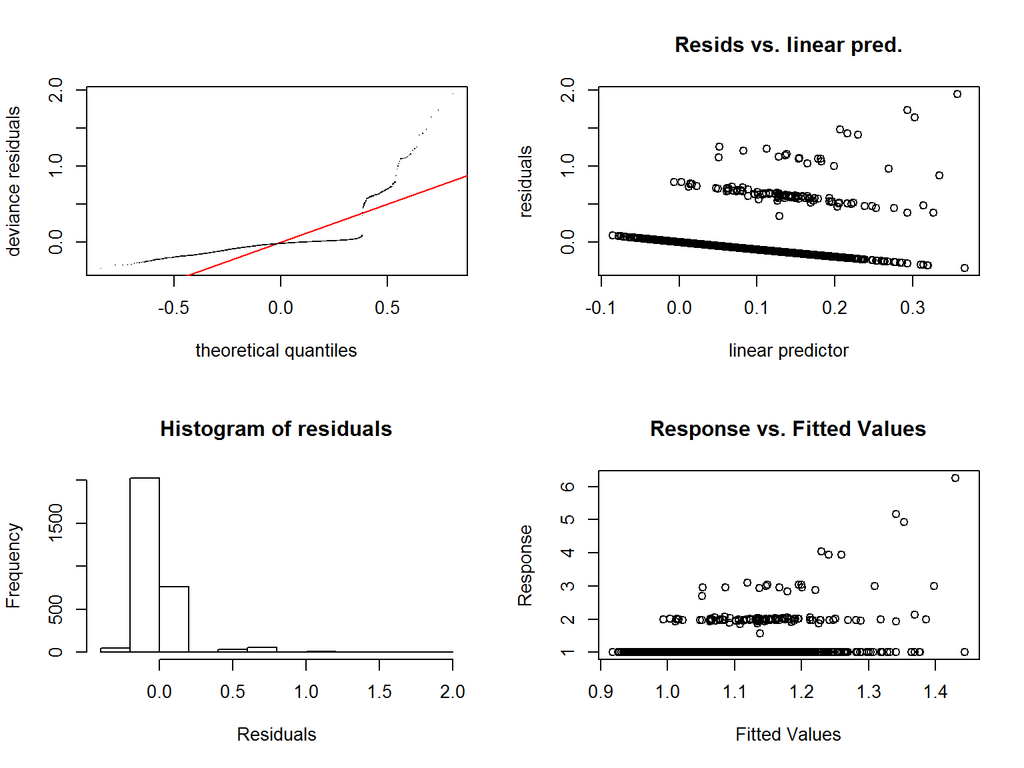

```
##
## Method: GCV   Optimizer: outer newton
## full convergence after 7 iterations.
## Gradient range [-4.402618e-08,1.200203e-08]
## (score 0.03246134 & scale 0.05302506).
## Hessian positive definite, eigenvalue range [4.386558e-08,0.0001297114].
## Model rank =  255 / 255
##
## Basis dimension (k) checking results. Low p-value (k-index<1) may
## indicate that k is too low, especially if edf is close to k'.
##
##                          k'    edf k-index p-value
## s(STARTLON,STARTLAT) 119.00  72.74    1.06    0.98
## s(AVG.DEPTH)          59.00  24.38    1.01    0.68
## s(SALBOTM)            58.00   1.01    1.02    0.95
## s(YEAR)               18.00  10.96      NA      NA
```

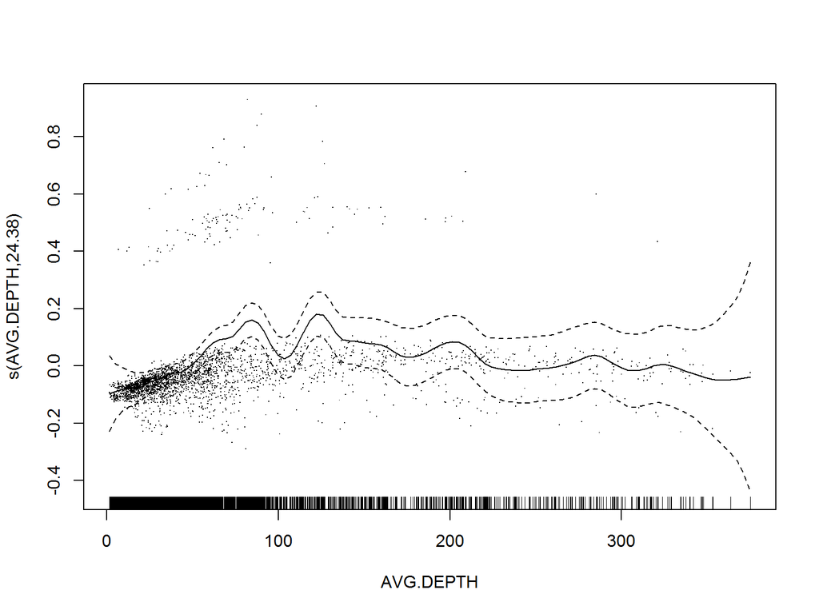

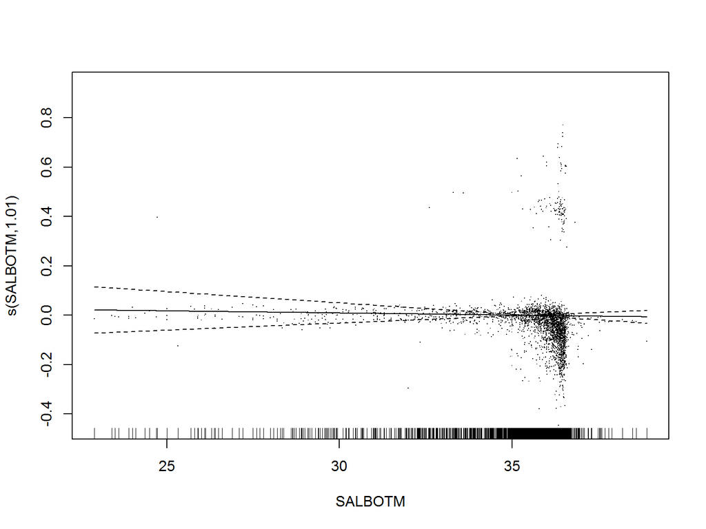

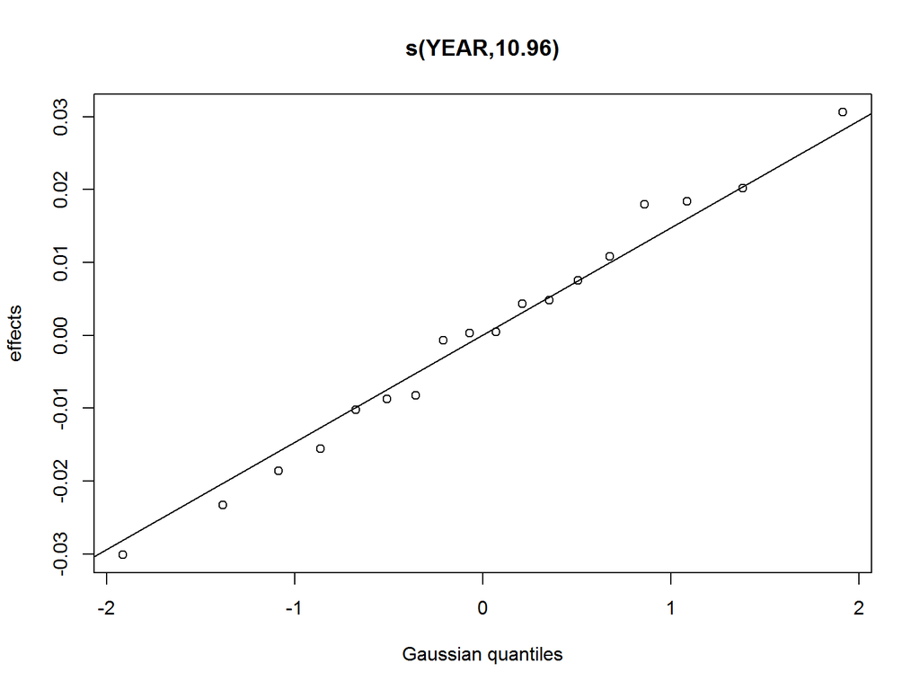

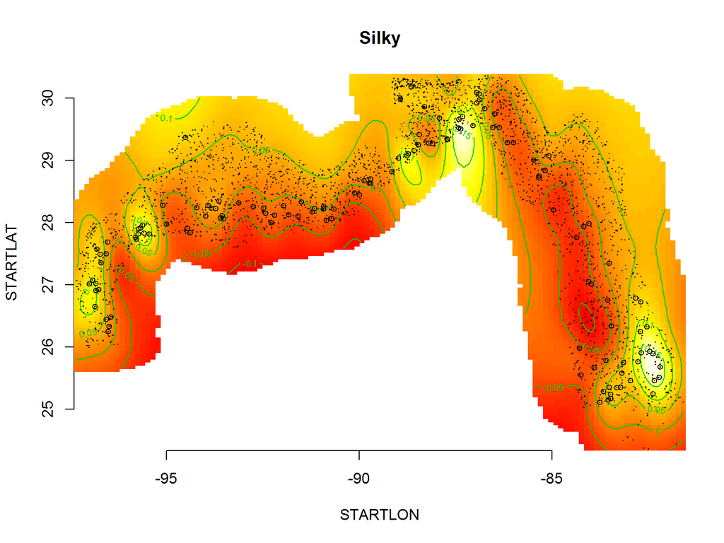

### Spinner

```
##
## Family: Gamma
## Link function: log
##
## Formula:
## (cpe + 1) ~ s(STARTLON, STARTLAT, k = est_k(dat)$lat + est_k(dat)$lon) +
##     s(AVG.DEPTH, k = est_k(dat)$dep) + s(OXYBOTM, k = est_k(dat)$oxy) +
##     s(SALBOTM, k = est_k(dat)$sal) + s(YEAR, bs = "re", k = 18)
##
## Parametric coefficients:
##             Estimate Std. Error t value Pr(>|t|)
## (Intercept)  0.16067    0.02761    5.82 6.56e-09 ***
## ---
## Signif. codes:  0 '***' 0.001 '**' 0.01 '*' 0.05 '.' 0.1 ' ' 1
##
## Approximate significance of smooth terms:
##                        edf Ref.df     F  p-value
## s(STARTLON,STARTLAT) 96.68 111.78 4.077  < 2e-16 ***
## s(AVG.DEPTH)         22.43  27.85 0.807  0.74736
## s(OXYBOTM)           42.95  50.01 1.626  0.00374 **
## s(SALBOTM)           48.13  54.13 1.384  0.03210 *
## s(YEAR)              13.83  17.00 2.477 2.13e-05 ***
## ---
## Signif. codes:  0 '***' 0.001 '**' 0.01 '*' 0.05 '.' 0.1 ' ' 1
##
## R-sq.(adj) =  0.214   Deviance explained = 59.3%
## GCV = 0.15986  Scale est. = 0.30005   n = 2963
```

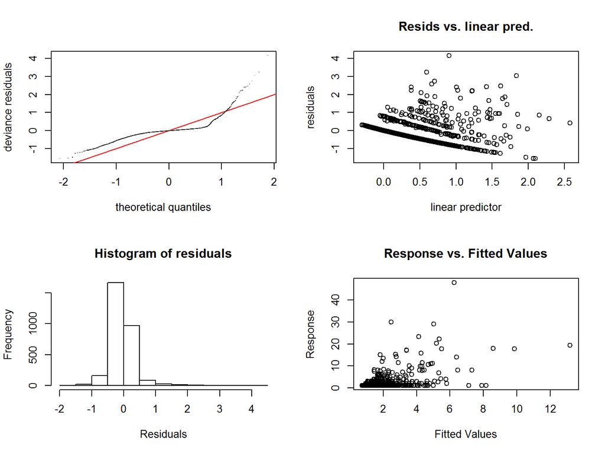

```
##
## Method: GCV   Optimizer: outer newton
## full convergence after 10 iterations.
## Gradient range [-9.902715e-11,1.014917e-08]
## (score 0.1598598 & scale 0.3000525).
## Hessian positive definite, eigenvalue range [0.0001406372,0.001082208].
## Model rank =  313 / 313
##
## Basis dimension (k) checking results. Low p-value (k-index<1) may
## indicate that k is too low, especially if edf is close to k'.
##
##                         k'   edf k-index p-value
## s(STARTLON,STARTLAT) 119.0  96.7    0.96   0.170
## s(AVG.DEPTH)          59.0  22.4    0.95   0.025 *
## s(OXYBOTM)            58.0  43.0    1.00   0.835
## s(SALBOTM)            58.0  48.1    0.97   0.230
## s(YEAR)               18.0  13.8      NA      NA
## ---
## Signif. codes:  0 '***' 0.001 '**' 0.01 '*' 0.05 '.' 0.1 ' ' 1
```

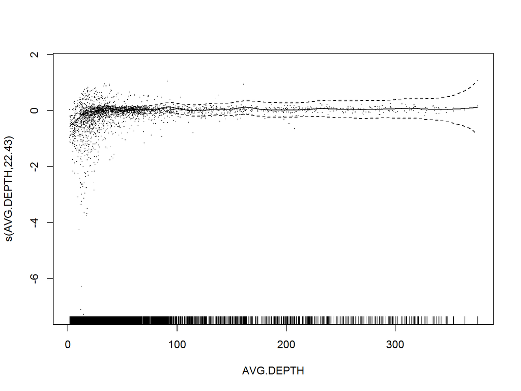

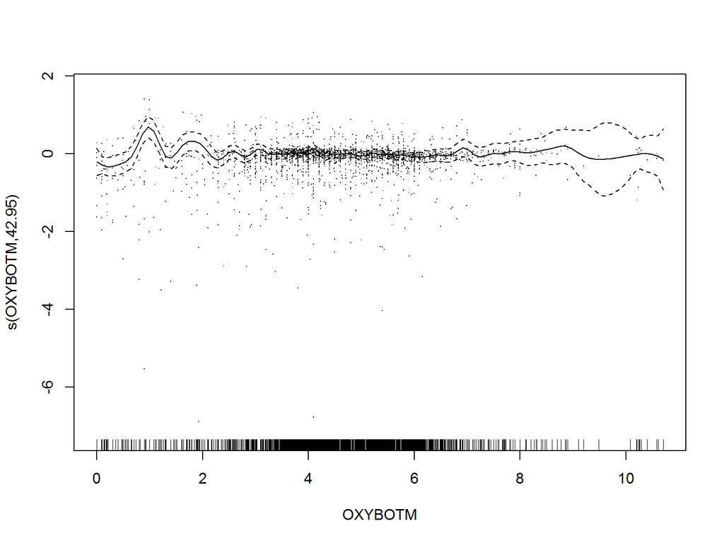

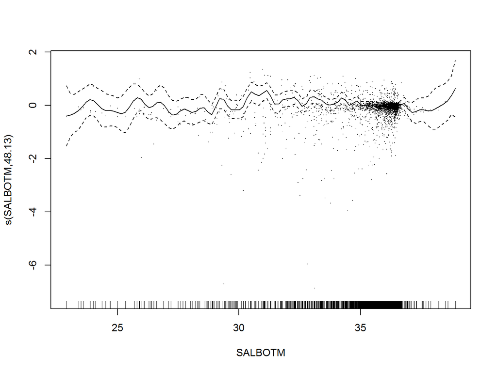

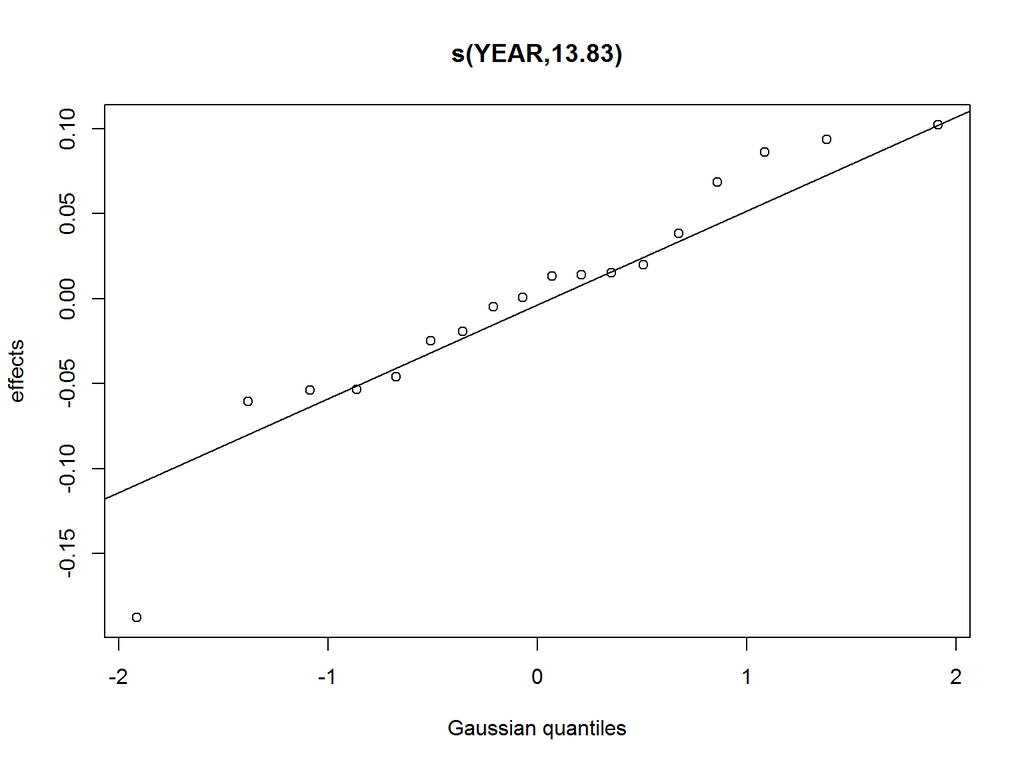

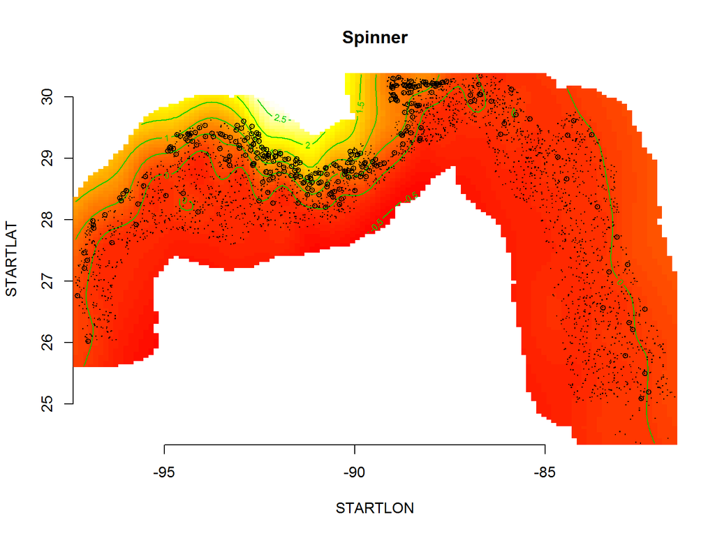

### Tiger

```
##
## Family: Gamma
## Link function: log
##
## Formula:
## (cpe + 1) ~ s(STARTLON, STARTLAT, k = est_k(dat)$lat + est_k(dat)$lon) +
##     s(AVG.DEPTH, k = est_k(dat)$dep) + s(OXYBOTM, k = est_k(dat)$oxy) +
##     s(SALBOTM, k = est_k(dat)$sal) + s(YEAR, bs = "re", k = 18)
##
## Parametric coefficients:
##             Estimate Std. Error t value Pr(>|t|)
## (Intercept)  0.09957    0.01315   7.574 4.88e-14 ***
## ---
## Signif. codes:  0 '***' 0.001 '**' 0.01 '*' 0.05 '.' 0.1 ' ' 1
##
## Approximate significance of smooth terms:
##                         edf Ref.df     F  p-value
## s(STARTLON,STARTLAT) 70.485 90.491 2.346 3.17e-11 ***
## s(AVG.DEPTH)         11.487 14.419 1.324 0.176954
## s(OXYBOTM)           43.826 50.782 2.142 5.59e-06 ***
## s(SALBOTM)            3.252  4.134 3.555 0.006230 **
## s(YEAR)              12.626 17.000 1.878 0.000468 ***
## ---
## Signif. codes:  0 '***' 0.001 '**' 0.01 '*' 0.05 '.' 0.1 ' ' 1
##
## R-sq.(adj) =  0.109   Deviance explained = 26.9%
## GCV = 0.06631  Scale est. = 0.10271   n = 2963
```

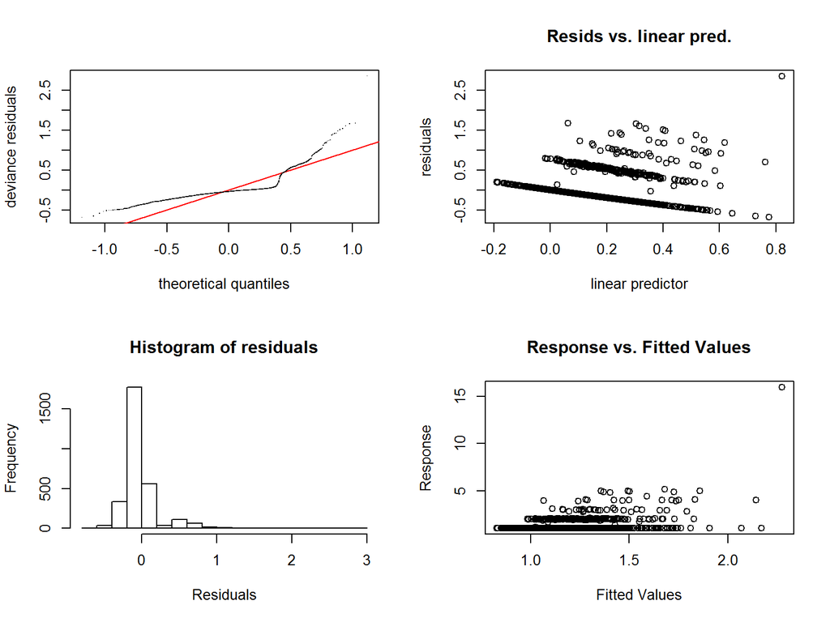

```
##
## Method: GCV   Optimizer: outer newton
## full convergence after 6 iterations.
## Gradient range [-1.080259e-10,5.014445e-09]
## (score 0.06631007 & scale 0.102708).
## Hessian positive definite, eigenvalue range [3.325442e-05,0.000322393].
## Model rank =  313 / 313
##
## Basis dimension (k) checking results. Low p-value (k-index<1) may
## indicate that k is too low, especially if edf is close to k'.
##
##                          k'    edf k-index p-value
## s(STARTLON,STARTLAT) 119.00  70.49    1.01    0.80
## s(AVG.DEPTH)          59.00  11.49    0.98    0.31
## s(OXYBOTM)            58.00  43.83    0.96    0.02 *
## s(SALBOTM)            58.00   3.25    0.98    0.21
## s(YEAR)               18.00  12.63      NA      NA
## ---
## Signif. codes:  0 '***' 0.001 '**' 0.01 '*' 0.05 '.' 0.1 ' ' 1
```

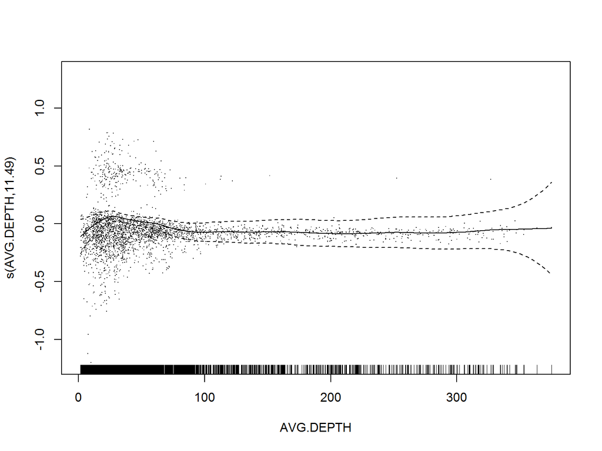

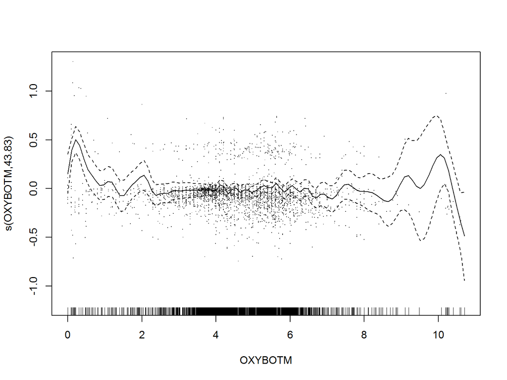

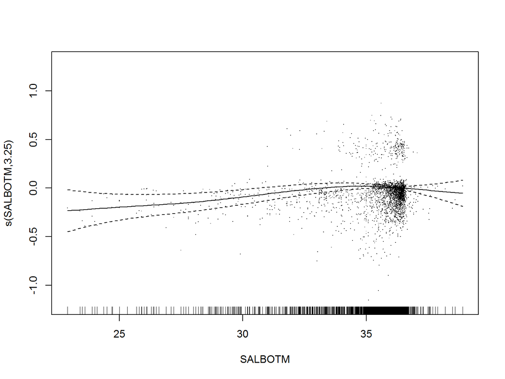

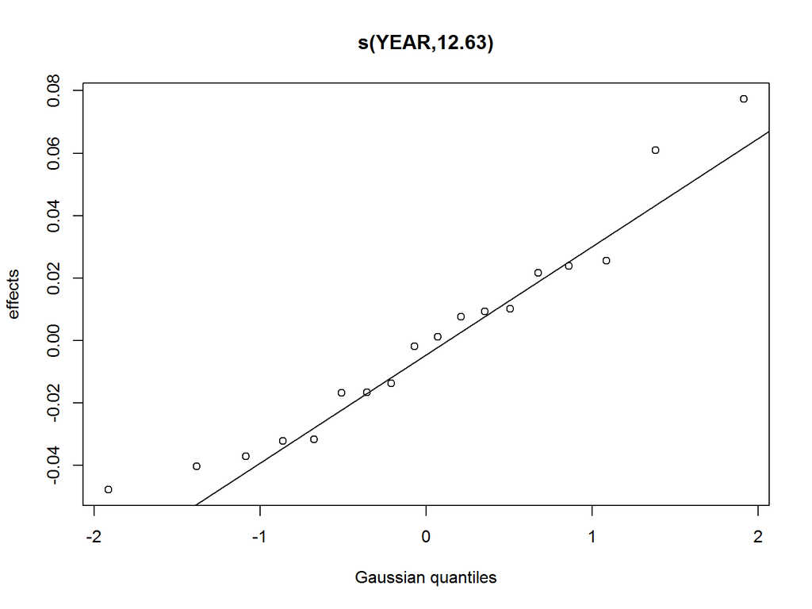

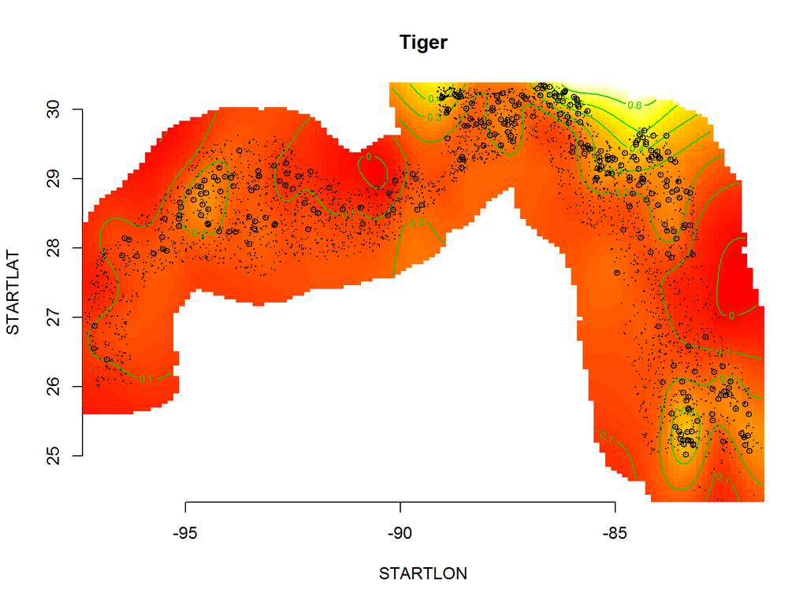

## Additional model comparisons

### Blacknose

```r
bn_gam_select_1$results
```

| model | NoOfCoef | AIC | BIC | GCV |
| --- | --- | --- | --- | --- |
| Lon, Lat, Lat-Lon, Dep, Oxy, Sal, Yr | 7 | 6797.959 | 7769.894 | 0.3196816 |
| Lat, Lat-Lon, Dep, Oxy, Sal, Yr | 6 | 6797.959 | 7769.893 | 0.3196816 |
| Lon, Lat-Lon, Dep, Oxy, Sal, Yr | 6 | 6839.971 | 7771.304 | 0.3232233 |
| Lat-Lon, Dep, Oxy, Sal, Yr | 5 | 6839.971 | 7771.304 | 0.3232233 |
| Lon, Lat, Lat-Lon, Dep, Sal, Yr | 6 | 6843.308 | 7800.578 | 0.3220880 |
| Lat, Lat-Lon, Dep, Sal, Yr | 5 | 6843.308 | 7800.578 | 0.3220880 |
| Lon, Lat, Lat-Lon, Dep, Oxy, Yr | 6 | 6862.384 | 7632.714 | 0.3221866 |
| Lat, Lat-Lon, Dep, Oxy, Yr | 5 | 6862.386 | 7632.703 | 0.3221866 |
| Lat, Lat-Lon, Oxy, Yr | 4 | 6873.797 | 7666.421 | 0.3236237 |
| Lon, Lat, Lat-Lon, Oxy, Yr | 5 | 6873.798 | 7666.416 | 0.3236237 |

[output cut: 117 more lines]

Number of models 127

user system elapsed

4.43 3.02 1239.10 $\approx$ 20 min

### Blacktip

```r
bt_gam_select$results
```

| model | NoOfCoef | AIC | BIC | GCV |
| --- | --- | --- | --- | --- |
| Lat, Lat-Lon, Dep, Oxy, Sal, Yr | 6 | 5783.867 | 6734.395 | 0.2512818 |
| Lon, Lat, Lat-Lon, Dep, Oxy, Sal, Yr | 7 | 5783.872 | 6734.373 | 0.2512818 |
| Lon, Lat-Lon, Dep, Oxy, Sal, Yr | 6 | 5784.755 | 6732.024 | 0.2513041 |
| Lat-Lon, Dep, Oxy, Sal, Yr | 5 | 5784.755 | 6732.024 | 0.2513041 |
| Lat, Lat-Lon, Oxy, Sal, Yr | 5 | 5822.758 | 6778.096 | 0.2544348 |
| Lon, Lat, Lat-Lon, Oxy, Sal, Yr | 6 | 5823.143 | 6776.854 | 0.2544411 |
| Lon, Lat-Lon, Oxy, Sal, Yr | 5 | 5823.145 | 6776.850 | 0.2544412 |
| Lat-Lon, Oxy, Sal, Yr | 4 | 5823.147 | 6776.843 | 0.2544412 |
| Lon, Lat, Lat-Lon, Dep, Sal, Yr | 6 | 5838.285 | 6772.184 | 0.2537508 |
| Lat, Lat-Lon, Dep, Sal, Yr | 5 | 5838.334 | 6771.966 | 0.2537507 |

[output cut: 117 more lines]

Number of models 127

user system elapsed

3.72 2.60 1291.12 $\approx$ 21 min

### Bull

```r
bu_gam_select$results
```

| model | NoOfCoef | AIC | BIC | GCV |
| --- | --- | --- | --- | --- |
| Lat, Lat-Lon, Oxy, Sal | 4 | 53.08205 | 1078.9386 | 0.05577072 |
| Lon, Lat, Lat-Lon, Oxy, Sal, Yr | 6 | 77.07226 | 944.1361 | 0.05570024 |
| Lat, Lat-Lon, Oxy, Sal, Yr | 5 | 77.07608 | 944.1152 | 0.05570023 |
| Lon, Lat-Lon, Dep, Oxy, Sal, Yr | 6 | 80.01999 | 1051.9034 | 0.05609576 |
| Lat-Lon, Dep, Oxy, Sal, Yr | 5 | 80.02003 | 1051.9030 | 0.05609576 |
| Lat, Lat-Lon, Dep, Oxy, Sal, Yr | 6 | 87.56724 | 938.7541 | 0.05584494 |
| Lon, Lat, Lat-Lon, Dep, Oxy, Sal, Yr | 7 | 87.56786 | 938.7587 | 0.05584496 |
| Lon, Lat, Lat-Lon, Oxy, Sal | 5 | 91.82364 | 921.4689 | 0.05585636 |
| Lon, Lat, Lat-Lon, Dep, Sal, Yr | 6 | 96.78555 | 856.4749 | 0.05573273 |
| Lat, Lat-Lon, Dep, Sal, Yr | 5 | 96.78582 | 856.4766 | 0.05573274 |

[output cut: 117 more lines]

Number of models 127

user system elapsed

1.94 2.45 1161.04 $\approx$ 19 min

### Sandbar

```r
sb_gam_select$results
```

| model | NoOfCoef | AIC | BIC | GCV |
| --- | --- | --- | --- | --- |
| Lon, Lat, Lat-Lon, Dep, Oxy, Sal, Yr | 7 | 2889.232 | 3487.723 | 0.1234186 |
| Lat, Lat-Lon, Dep, Oxy, Sal, Yr | 6 | 2889.232 | 3487.723 | 0.1234186 |
| Lon, Lat-Lon, Dep, Oxy, Sal, Yr | 6 | 2892.681 | 3489.384 | 0.1235476 |
| Lat-Lon, Dep, Oxy, Sal, Yr | 5 | 2892.683 | 3489.372 | 0.1235476 |
| Lon, Lat, Lat-Lon, Dep, Oxy, Yr | 6 | 2892.813 | 3471.181 | 0.1233975 |
| Lat, Lat-Lon, Dep, Oxy, Yr | 5 | 2892.813 | 3471.180 | 0.1233975 |
| Lon, Lat, Lat-Lon, Dep, Sal, Yr | 6 | 2896.432 | 3450.720 | 0.1231635 |
| Lat, Lat-Lon, Dep, Sal, Yr | 5 | 2896.433 | 3450.711 | 0.1231635 |
| Lon, Lat-Lon, Dep, Oxy, Yr | 5 | 2896.668 | 3474.222 | 0.1235497 |
| Lat-Lon, Dep, Oxy, Yr | 4 | 2896.669 | 3474.214 | 0.1235497 |

[output cut: 117 more lines]

Number of models 127

user system elapsed

1.77 2.87 746.13 $\approx$ 12 min

### Sharpnose

```r
sn_gam_select_2$results
```

| model | NoOfCoef | AIC | BIC | GCV |
| --- | --- | --- | --- | --- |
| Lon, Lat, Lat-Lon, Dep, temp, Oxy, Sal, Yr | 8 | 12763.78 | 13704.87 | 0.6979028 |
| Lat, Lat-Lon, Dep, temp, Oxy, Sal, Yr | 7 | 12771.40 | 13682.59 | 0.6981341 |
| Lon, Lat-Lon, Dep, temp, Oxy, Sal, Yr | 7 | 12782.77 | 13664.87 | 0.6992166 |
| Lat-Lon, Dep, temp, Oxy, Sal, Yr | 6 | 12782.77 | 13664.87 | 0.6992171 |
| Lon, Lat, Lat-Lon, Dep, temp, Oxy, Yr | 7 | 12813.49 | 13729.72 | 0.7068986 |
| Lon, Lat, Lat-Lon, temp, Oxy, Sal, Yr | 7 | 12821.52 | 14107.03 | 0.7271715 |
| Lat, Lat-Lon, Dep, temp, Oxy, Yr | 6 | 12822.84 | 13702.60 | 0.7072010 |
| Lon, Lat, Lat-Lon, Dep, temp, Sal, Yr | 7 | 12831.80 | 13715.59 | 0.7026393 |
| Lat, Lat-Lon, Dep, temp, Sal, Yr | 6 | 12831.80 | 13715.59 | 0.7026394 |
| Lon, Lat-Lon, Dep, temp, Oxy, Yr | 6 | 12836.74 | 13678.89 | 0.7084488 |

[output cut: 245 more lines]

Number of models 255

user system elapsed

3.92 5.59 4214.18 $\approx$ 1 hr 10 min

### Silky

```r
si_gam_select$results
```

| model | NoOfCoef | AIC | BIC | GCV |
| --- | --- | --- | --- | --- |
| Lon, Lat, Dep, Sal, Yr | 5 | -1536.578 | -1143.4725 | 0.03314482 |
| Lon, Lat, Lat-Lon, Dep, Sal, Yr | 6 | -1535.131 | -1123.1109 | 0.03319260 |
| Lon, Lat, Dep, Oxy, Yr | 5 | -1527.484 | -1134.0843 | 0.03320299 |
| Lon, Lat, Dep, Oxy, Sal, Yr | 6 | -1524.696 | -1125.9300 | 0.03323690 |
| Lon, Lat-Lon, Dep, Oxy, Sal, Yr | 6 | -1523.522 | -1105.4415 | 0.03328264 |
| Lon, Lat-Lon, Dep, Sal, Yr | 5 | -1517.418 | -1164.5095 | 0.03329097 |
| Lat-Lon, Dep, Sal, Yr | 4 | -1517.417 | -1164.5098 | 0.03329097 |
| Lat, Lat-Lon, Dep, Sal, Yr | 5 | -1517.417 | -1164.5059 | 0.03329098 |
| Lon, Lat, Dep, Sal | 4 | -1514.598 | -1169.3096 | 0.03330977 |
| Lon, Lat-Lon, Dep, Oxy, Yr | 5 | -1513.996 | -1110.9079 | 0.03337001 |

[output cut: 117 more lines]

Number of models 127

### Spinner

```r
sp_gam_select$results
```

| model | NoOfCoef | AIC | BIC | GCV |
| --- | --- | --- | --- | --- |
| Lon, Lat, Lat-Lon, Dep, Oxy, Sal, Yr | 7 | 3704.023 | 4685.214 | 0.1692529 |
| Lat, Lat-Lon, Dep, Oxy, Sal, Yr | 6 | 3714.595 | 4652.140 | 0.1693956 |
| Lon, Lat, Lat-Lon, Oxy, Sal, Yr | 6 | 3719.896 | 4619.641 | 0.1692462 |
| Lon, Lat-Lon, Oxy, Sal, Yr | 5 | 3725.394 | 4612.577 | 0.1694262 |
| Lat, Lat-Lon, Oxy, Sal, Yr | 5 | 3727.551 | 4595.385 | 0.1693520 |
| Lon, Lat-Lon, Dep, Oxy, Sal, Yr | 6 | 3727.819 | 4621.247 | 0.1696864 |
| Lat-Lon, Oxy, Sal, Yr | 4 | 3733.101 | 4589.026 | 0.1695424 |
| Lat-Lon, Dep, Oxy, Sal, Yr | 5 | 3737.964 | 4591.823 | 0.1698553 |
| Lon, Lat, Lat-Lon, Dep, Oxy, Yr | 6 | 3739.184 | 4719.587 | 0.1711542 |
| Lon, Lat-Lon, Dep, Oxy, Yr | 5 | 3745.740 | 4715.795 | 0.1714164 |

[output cut: 117 more lines]

Number of models 127

### Tiger

```r
ti_gam_select$results
```

| model | NoOfCoef | AIC | BIC | GCV |
| --- | --- | --- | --- | --- |
| Lon, Lat, Lat-Lon, Dep, Oxy, Sal, Yr | 7 | 832.4169 | 1476.996 | 0.06869162 |
| Lat, Lat-Lon, Dep, Oxy, Sal, Yr | 6 | 832.4350 | 1476.898 | 0.06869160 |
| Lat, Lat-Lon, Dep, Oxy, Yr | 5 | 848.7440 | 1498.855 | 0.06908386 |
| Lon, Lat, Lat-Lon, Dep, Oxy, Yr | 6 | 848.7519 | 1498.825 | 0.06908390 |
| Lon, Lat-Lon, Dep, Oxy, Sal, Yr | 6 | 856.4772 | 1379.438 | 0.06879485 |
| Lat-Lon, Dep, Oxy, Sal, Yr | 5 | 856.4805 | 1379.417 | 0.06879483 |
| Lon, Lat, Lat-Lon, Oxy, Sal, Yr | 6 | 859.8219 | 1394.626 | 0.06891081 |
| Lat, Lat-Lon, Oxy, Sal, Yr | 5 | 859.8219 | 1394.626 | 0.06891081 |
| Lon, Lat-Lon, Oxy, Sal, Yr | 5 | 859.8229 | 1394.605 | 0.06891076 |
| Lat-Lon, Oxy, Sal, Yr | 4 | 859.8233 | 1394.601 | 0.06891075 |

[output cut: 117 more lines]

Number of models 127

## Model selection Function

```r
gam_select_fn <- function(data = data,
                          smooth_terms = smooth_terms,
                          names = names,
                          response = response,
                          gamma = NULL,
                          choose_k = FALSE,
                          dim_k = NULL,
                          family = Gamma(link = log),
                          in_parallel = FALSE){
  require(mgcv)
  require(magrittr)
  require(plyr)
  require(dplyr)

  if(in_parallel == TRUE){

    require(parallel)
    require(snow)

  }

  source("k_est_fn.R")

  ### Options for gamma

  if(is.null(gamma) == TRUE){
    gamma = 1
  } else{
    gamma = gamma
  }

  ### Options for k

  if(choose_k == FALSE & is.null(dim_k) == TRUE){

    ### use default k values
    k_lon = 10
    k_lat = 10
    k_dep = 10
    k_temp = 10
    k_oxy = 10
    k_sal = 10
    k_yr = 10

  } else if(choose_k == TRUE & is.null(dim_k) == TRUE){

    ### estimate k values based on data
    k_lon = est_k(data)$lon
    k_lat = est_k(data)$lat
    k_dep = est_k(data)$dep
    k_temp = est_k(data)$temp
    k_oxy = est_k(data)$oxy
    k_sal = est_k(data)$sal
    k_yr = length((unique(data$YEAR)))

  } else if(choose_k == FALSE & is.list(dim_k) == TRUE){

    ### use list of user defined k values
    k_lon = dim_k$k_lon
    k_lat = dim_k$k_lat
    k_dep = dim_k$k_dep
    k_temp = dim_k$k_temp
    k_oxy = dim_k$k_oxy
    k_sal = dim_k$k_sal
    k_yr = dim_k$k_yr

  } else if(choose_k != TRUE & choose_k != FALSE){

    stop("choose_k must be TRUE or FALSE.")

  } else{
    stop("dim_k must be provided as a list and arguments must match those in smooth_terms.")
  }

  ### create matrix of all variable combinations
  N   <- length(smooth_terms)
  vec <- c(TRUE, FALSE)

  lst <- lapply(numeric(N), function(x) vec)


  regMat <- expand.grid(lst)

  ### Create all model Combinations

  regMat <- regMat[-(dim(regMat)[1]),]
  names(regMat) <- c(names)

  all_Models_List <- apply(regMat, 1, function(x) as.formula(
    paste(c(response, paste(smooth_terms[x],
                            collapse = " + ")),
          collapse = " ~ ")) )

  ### Fit All Model Combinations

  if(in_parallel == FALSE){

    all_Models_Results <- lapply(all_Models_List,
                                 function(x) gam(x, data = data,
                                                 family = family,
                                                 gamma = gamma))

  } else if(in_parallel == TRUE){

    no_cores <- detectCores()

    cl <- makeCluster(no_cores)

    environment(all_Models_List) <- .GlobalEnv

    clusterExport(cl, list(data = "data", smooth_terms = "smooth_terms", names = "names", response = "response",
                           gamma = "gamma", choose_k = "choose_k", dim_k = "dim_k", family = "family",
                           k_lon = "k_lon", k_lat = "k_lat", k_dep = "k_dep", k_oxy = "k_oxy", k_sal = "k_sal", k_yr = "k_yr",
                           regMat = "regMat", all_Models_List = "all_Models_List"),
                  envir = environment())

    clusterEvalQ(cl, c(require(mgcv), require(dplyr), require(magrittr), require(plyr),require(parallel),
                       require(snow), source("k_est_fn.R")))


    all_Models_Results <- parLapply(cl,
                                    all_Models_List,
                                    function(x) gam(x, data = data,
                                                    family = family,
                                                    gamma = gamma))

    stopCluster(cl)

  }

  ### Clean Names

  Name_List <- apply(regMat, 1, function(x)
    paste(names[x],collapse = ", ") )

  mod_names <- apply(regMat, 1, function(x)
    paste(names[x],collapse = "_") )

  names(all_Models_Results) <- unlist(mod_names)

  ### Summary Stats

  NoOfCoef <- unlist(apply(regMat, 1, sum))

  AIC <- unlist(lapply(all_Models_Results, function(x)
    AIC(x)))

  BIC <- unlist(lapply(all_Models_Results, function(x)
    BIC(x)))

  GCV <- unlist(lapply(all_Models_Results, function(x)
    x$gcv.ubre))

  ### Create results df

  results <- data.frame( model = unlist(Name_List),
                         NoOfCoef = NoOfCoef,
                         AIC = AIC,
                         BIC = BIC,
                         GCV = GCV) %>%
    arrange(AIC)

  ### Make list of model results and fitted objects

  Output <- list(results = results,
                 model_fits = all_Models_Results)


  return(Output)

}
```

### k_est_fn

```r
est_k <- function(dat){
  require(magrittr)

  var_list <- c( "STARTLAT", "STARTLON", "AVG.DEPTH", "TEMPBOTM", "TURBBOTM", "OXYBOTM", "SALBOTM")

  dat %<>% select(var_list)

  k_est <- data.frame(lat = numeric(1),
                      lon = numeric(1),
                      dep = numeric(1),
                      temp = numeric(1),
                      turb = numeric(1),
                      oxy = numeric(1),
                      sal = numeric(1))

  n_dat <- numeric(ncol(dat))


for(i in 1:ncol(dat)){
  n_dat[i] = length(which(is.na(dat[,i]) == FALSE))
  k_est[i] = round(10*(n_dat[i]^(2/9)))
}

return(k_est)
}
```